# CA0 - Introduction to AI

```python
import numpy as np
import pandas as pd
import matplotlib.pyplot as plt
import scipy.stats as stats
from scipy.stats import norm
import math
import time
```

## part 1

1. head(): returns the first 5 rows of df.
2. tall(): returns the last 5 rows of df.
3. describe(): returns informations such as mean, min, std, and count about every columnn of data in df.

```python
df = pd.read_csv('advertising_dataset.csv', index_col=0)
df
```

|  | Daily Time Spent on Site | Age | Area Income | Daily Internet Usage | Ad Topic Line | City | Gender | Country | Timestamp | Clicked on Ad |
| --- | --- | --- | --- | --- | --- | --- | --- | --- | --- | --- |
| 0 | 68.95 | 35.0 | 61833.90 | 256.09 | Cloned 5thgeneration orchestration | Wrightburgh | Female | Tunisia | 2016-03-27 00:53:11 | 0.0 |
| 1 | 80.23 | 31.0 | 68441.85 | NaN | Monitored national standardization | West Jodi | Male | Nauru | 2016-04-04 01:39:02 | 0.0 |
| 2 | 69.47 | 26.0 | 59785.94 | 236.50 | Organic bottom-line service-desk | Davidton | Female | San Marino | 2016-03-13 20:35:42 | 0.0 |
| 3 | 74.15 | 29.0 | 54806.18 | 245.89 | Triple-buffered reciprocal time-frame | West Terrifurt | Male | Italy | 2016-01-10 02:31:19 | 0.0 |
| 4 | 68.37 | 35.0 | 73889.99 | 225.58 | Robust logistical utilization | South Manuel | Female | Iceland | 2016-06-03 03:36:18 | 0.0 |
| ... | ... | ... | ... | ... | ... | ... | ... | ... | ... | ... |
| 995 | 72.97 | 30.0 | 71384.57 | 208.58 | Fundamental modular algorithm | Duffystad | Male | Lebanon | 2016-02-11 21:49:00 | 1.0 |
| 996 | 51.30 | 45.0 | 67782.17 | 134.42 | Grass-roots cohesive monitoring | New Darlene | Male | Bosnia and Herzegovina | 2016-04-22 02:07:01 | 1.0 |
| 997 | 51.63 | 51.0 | 42415.72 | 120.37 | Expanded intangible solution | South Jessica | Male | Mongolia | 2016-02-01 17:24:57 | 1.0 |
| 998 | 55.55 | 19.0 | 41920.79 | 187.95 | Proactive bandwidth-monitored policy | West Steven | Female | Guatemala | 2016-03-24 02:35:54 | 0.0 |
| 999 | NaN | 26.0 | 29875.80 | 178.35 | Virtual 5thgeneration emulation | Ronniemouth | Female | Brazil | 2016-06-03 21:43:21 | 1.0 |

1000 rows × 10 columns

```python
df.head()
```

|  | Daily Time Spent on Site | Age | Area Income | Daily Internet Usage | Ad Topic Line | City | Gender | Country | Timestamp | Clicked on Ad |
| --- | --- | --- | --- | --- | --- | --- | --- | --- | --- | --- |
| 0 | 68.95 | 35.0 | 61833.90 | 256.09 | Cloned 5thgeneration orchestration | Wrightburgh | Female | Tunisia | 2016-03-27 00:53:11 | 0.0 |
| 1 | 80.23 | 31.0 | 68441.85 | NaN | Monitored national standardization | West Jodi | Male | Nauru | 2016-04-04 01:39:02 | 0.0 |
| 2 | 69.47 | 26.0 | 59785.94 | 236.50 | Organic bottom-line service-desk | Davidton | Female | San Marino | 2016-03-13 20:35:42 | 0.0 |
| 3 | 74.15 | 29.0 | 54806.18 | 245.89 | Triple-buffered reciprocal time-frame | West Terrifurt | Male | Italy | 2016-01-10 02:31:19 | 0.0 |
| 4 | 68.37 | 35.0 | 73889.99 | 225.58 | Robust logistical utilization | South Manuel | Female | Iceland | 2016-06-03 03:36:18 | 0.0 |

```python
df.tail()
```

|  | Daily Time Spent on Site | Age | Area Income | Daily Internet Usage | Ad Topic Line | City | Gender | Country | Timestamp | Clicked on Ad |
| --- | --- | --- | --- | --- | --- | --- | --- | --- | --- | --- |
| 995 | 72.97 | 30.0 | 71384.57 | 208.58 | Fundamental modular algorithm | Duffystad | Male | Lebanon | 2016-02-11 21:49:00 | 1.0 |
| 996 | 51.30 | 45.0 | 67782.17 | 134.42 | Grass-roots cohesive monitoring | New Darlene | Male | Bosnia and Herzegovina | 2016-04-22 02:07:01 | 1.0 |
| 997 | 51.63 | 51.0 | 42415.72 | 120.37 | Expanded intangible solution | South Jessica | Male | Mongolia | 2016-02-01 17:24:57 | 1.0 |
| 998 | 55.55 | 19.0 | 41920.79 | 187.95 | Proactive bandwidth-monitored policy | West Steven | Female | Guatemala | 2016-03-24 02:35:54 | 0.0 |
| 999 | NaN | 26.0 | 29875.80 | 178.35 | Virtual 5thgeneration emulation | Ronniemouth | Female | Brazil | 2016-06-03 21:43:21 | 1.0 |

```python
df.describe()
```

|  | Daily Time Spent on Site | Age | Area Income | Daily Internet Usage | Clicked on Ad |
| --- | --- | --- | --- | --- | --- |
| count | 907.000000 | 979.000000 | 1000.000000 | 913.000000 | 832.000000 |
| mean | 64.794818 | 36.009193 | 55000.000080 | 179.751271 | 0.496394 |
| std | 15.954841 | 8.783636 | 13414.634022 | 43.957934 | 0.500288 |
| min | 32.600000 | 19.000000 | 13996.500000 | 104.780000 | 0.000000 |
| 25% | 50.615000 | 29.000000 | 47031.802500 | 138.550000 | 0.000000 |
| 50% | 67.940000 | 35.000000 | 57012.300000 | 183.480000 | 0.000000 |
| 75% | 78.555000 | 42.000000 | 65470.635000 | 217.850000 | 1.000000 |
| max | 91.430000 | 61.000000 | 79484.800000 | 269.960000 | 1.000000 |

## part 2

1. info(): returns the number of not-null values and data type of each column.

```python
df.info()
```

```
<class 'pandas.core.frame.DataFrame'>
Int64Index: 1000 entries, 0 to 999
Data columns (total 10 columns):
 #   Column                    Non-Null Count  Dtype
---  ------                    --------------  -----
 0   Daily Time Spent on Site  907 non-null    float64
 1   Age                       979 non-null    float64
 2   Area Income               1000 non-null   float64
 3   Daily Internet Usage      913 non-null    float64
 4   Ad Topic Line             1000 non-null   object
 5   City                      1000 non-null   object
 6   Gender                    1000 non-null   object
 7   Country                   1000 non-null   object
 8   Timestamp                 1000 non-null   object
 9   Clicked on Ad             832 non-null    float64
dtypes: float64(5), object(5)
memory usage: 85.9+ KB
```

## part 2_1

1. map(): Map values of Series according to input correspondence, used for substituting each value in a Series with another value, that may be derived from a function, a dict or a Series.

```python
df['Gender'] = df['Gender'].map({'Female': 0, 'Male': 1})
```

## part 3

1.isna(): returns a boolean result which shows if each element is NaN or not. Combined with sum() function, this method will be applied to the whole Series/Dataframe and return count of NaN values encountered

#### Alternate Method of fill:

2.ffill(): When ffill() is applied across the index then any missing value is filled based on the corresponding value in the previous row.

```python
for i in df.columns:
    print(i, ': ', df[i].isna().sum())
target_column = df['Clicked on Ad']
df = df.loc[:, df.columns.difference(['Clicked on Ad'])].fillna(df.mean())
df['Clicked on Ad'] = target_column
print("######### Result after filling NaN values: #########")
for i in df.columns:
    print(i, ': ', df[i].isna().sum())
```

```
Daily Time Spent on Site :  93
Age :  21
Area Income :  0
Daily Internet Usage :  87
Ad Topic Line :  0
City :  0
Gender :  0
Country :  0
Timestamp :  0
Clicked on Ad :  168
######### Result after filling NaN values: #########
Ad Topic Line :  0
Age :  0
Area Income :  0
City :  0
Country :  0
Daily Internet Usage :  0
Daily Time Spent on Site :  0
Gender :  0
Timestamp :  0
Clicked on Ad :  168
```

## part 4

1.value_counts(): Return a Series containing counts of unique values. Can also be applied on Dataframes.

```python
print('Number of Females: ', df['Gender'].value_counts()[0])
print('Number of Males: ', df['Gender'].value_counts()[1])
print('Number of Total Clicks: ', df['Clicked on Ad'].value_counts()[1])
print('Number of Total No-Clicks: ', df['Clicked on Ad'].value_counts()[0])
```

```
Number of Females:  519
Number of Males:  481
Number of Total Clicks:  413
Number of Total No-Clicks:  419
```

## part 5

1.index():Immutable ndarray implementing an ordered, sliceable set. The basic object storing axis labels for all pandas objects.

2.len(): Return Number of Present elements in a list. Used to count number of rows where applied on Dataframe.index

```python
len(df[(df['Age'] > 21) & (df['Gender'] == 1)].index)
```

```
468
```

## part 6

1.There are two ways to access a specific column from dataframe: First one is **df['column_name']** and Second one is to use **df.column_name**

2.mean(): When called upon a dataframe/series it will calculate mean of the (numeric) values present in dataframe/series. Note that this method is part of Vectorization functions

```python
tic = time.time()
temp_info = df.groupby(df['Clicked on Ad']).mean()
print("Avg Age for Clickers: ", temp_info['Age'][1])
print("Avg Age for Non-Clickers: ", temp_info['Age'][0])
toc = time.time()
print("Timing For Vectorization: %f ms" % ((toc - tic) * 1000))
```

```
Avg Age for Clickers:  40.295599848637366
Avg Age for Non-Clickers:  31.723325881701896
Timing For Vectorization: 2.988577 ms
```

## part 7

As we can see, using loops to do the job will result in a significant time loss. About 20X more time needed.

```python
tic = time.time()
clicked_sum = 0
clicked_count = 0
nonclicked_sum = 0
nonclicked_count = 0
for index, row in df.iterrows():
    if (row['Clicked on Ad'] == 1):
        clicked_sum += row['Age']
        clicked_count += 1
    elif (row['Clicked on Ad'] == 0):
        nonclicked_sum += row['Age']
        nonclicked_count += 1
print("Avg Age for Clickers: ", clicked_sum / clicked_count)
print("Avg Age for Non-Clickers: ", nonclicked_sum / nonclicked_count)

toc = time.time()
print("Timing For Vectorization: %f ms" % ((toc - tic) * 1000))
```

```
Avg Age for Clickers:  40.295599848637366
Avg Age for Non-Clickers:  31.723325881701896
Timing For Vectorization: 59.870720 ms
```

## part 8

1.hist(): A histogram is a representation of the distribution of data. This function calls matplotlib.pyplot.hist(), on each series in the DataFrame, resulting in one histogram per column. The size in inches of the figure to create is represented by figsize argument.

```
array([[<AxesSubplot:title={'center':'Age'}>,
        <AxesSubplot:title={'center':'Area Income'}>],
       [<AxesSubplot:title={'center':'Daily Internet Usage'}>,
        <AxesSubplot:title={'center':'Daily Time Spent on Site'}>],
       [<AxesSubplot:title={'center':'Gender'}>,
        <AxesSubplot:title={'center':'Clicked on Ad'}>]], dtype=object)
```

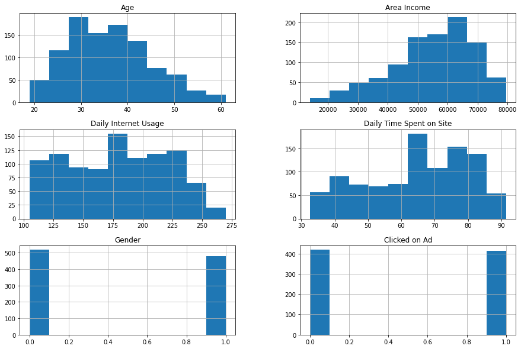

```python
df.hist(figsize = (15, 10))
```

## part 9

1.The SettingWithCopyWarning was created to flag potentially confusing "chained" assignments. So we tell pandas to ignore out false positive warning using pd.options.

2.By using mean() and std() on columns we use the built in function of Pandas on Series.

3.apply(): Used to apply a function to all the elements. Here the function is the normalizing of the values.

```python
pd.options.mode.chained_assignment = None
new_df = df[['Daily Time Spent on Site', 'Age', 'Area Income', 'Daily Internet Usage', 'Clicked on Ad']]
for i in new_df.columns:
    col_mean = new_df[i].mean()
    col_std = new_df[i].std()
    new_df[i] = new_df[i].apply(lambda x: ((x - col_mean) / col_std))

new_df
```

|  | Daily Time Spent on Site | Age | Area Income | Daily Internet Usage | Clicked on Ad |
| --- | --- | --- | --- | --- | --- |
| 0 | 0.273474 | -0.116122 | 0.509436 | 1.817578 | -0.992217 |
| 1 | 1.015870 | -0.576377 | 1.002029 | 0.000000 | -0.992217 |
| 2 | 0.307698 | -1.151696 | 0.356770 | 1.351152 | -0.992217 |
| 3 | 0.615713 | -0.806505 | -0.014448 | 1.574722 | -0.992217 |
| 4 | 0.235301 | -0.116122 | 1.408163 | 1.091154 | -0.992217 |
| ... | ... | ... | ... | ... | ... |
| 995 | 0.538051 | -0.691441 | 1.221395 | 0.686394 | 1.006632 |
| 996 | -0.888164 | 1.034517 | 0.952853 | -1.079309 | 1.006632 |
| 997 | -0.866445 | 1.724900 | -0.938101 | -1.413831 | 1.006632 |
| 998 | -0.608450 | -1.957144 | -0.974996 | 0.195207 | -0.992217 |
| 999 | 0.000000 | -1.151696 | -1.872895 | -0.033363 | 1.006632 |

1000 rows × 5 columns

## part 10

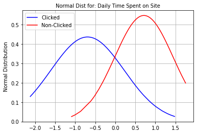

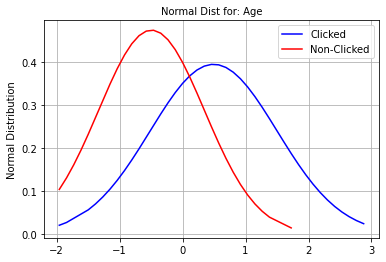

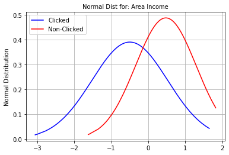

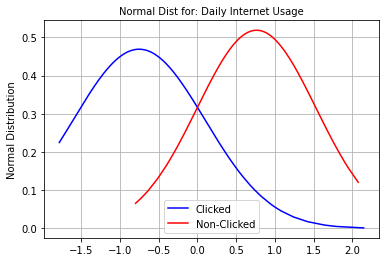

```python
clicked_df = new_df[new_df['Clicked on Ad'] > 1]
nonclicked_df = new_df[new_df['Clicked on Ad'] < 1]

feature_list = new_df.columns.tolist()[:-1]

for i in range(4):
    clicked_df = clicked_df.sort_values(by =feature_list[i] , ascending=True)
    nonclicked_df = nonclicked_df.sort_values(by =feature_list[i] , ascending=True)
    plt.plot(clicked_df[feature_list[i]], stats.norm.pdf(clicked_df[feature_list[i]], clicked_df.describe()[feature_list[i]]['mean'],
                                              math.sqrt(clicked_df.describe()[feature_list[i]]['std'])), color='b', label="Clicked")
    plt.plot(nonclicked_df[feature_list[i]], stats.norm.pdf(nonclicked_df[feature_list[i]], nonclicked_df.describe()[feature_list[i]]['mean'],
                                                 math.sqrt(nonclicked_df.describe()[feature_list[i]]['std'])), color='r', label="Non-Clicked")
    plt.title('Normal Dist for: ' + feature_list[i] ,fontsize=10)
    plt.ylabel('Normal Distribution')
    plt.grid()
    plt.legend()
    plt.show()
```

## part 11

```python
clk_mean = clicked_df.describe()['Daily Internet Usage']['mean']
clk_std = clicked_df.describe()['Daily Internet Usage']['std']
noclk_mean = nonclicked_df.describe()['Daily Internet Usage']['mean']
noclk_std = nonclicked_df.describe()['Daily Internet Usage']['std']

a = clk_mean - clk_std
b = clk_mean + clk_std

to_predict = new_df[new_df['Clicked on Ad'].isnull()]
to_predict['Clicked on Ad'] = np.where((a <= to_predict['Daily Internet Usage']) & (b >= to_predict['Daily Internet Usage']), 1, 0)
output = to_predict[['Clicked on Ad']]
output.to_csv('prediction_result.csv')
```